# Homework 02

Walid Hedidar

2/17/2021

**For this homework, I will will be working with the monthly_deaths data set. To start, I will be loading the data set in R.**

```r
knitr::opts_chunk$set(echo = TRUE)
library (tidyverse)
library (fmsb)
monthly_deaths<-read_csv("monthly_deaths.csv")
```

**Here, I add the variable inf_mortality**

```r
monthly_deaths$infant_mor<-monthly_deaths$deaths/monthly_deaths$births
```

**Here, I change dates into month format**

```r
monthly_deaths$month<-format(monthly_deaths$date, format="%m")
```

**Here, I change dates into year format**

```r
monthly_deaths$year<-format(monthly_deaths$date, format="%Y")
```

**Question 1: Here, I plot Mean IMR by Year** &nbsp

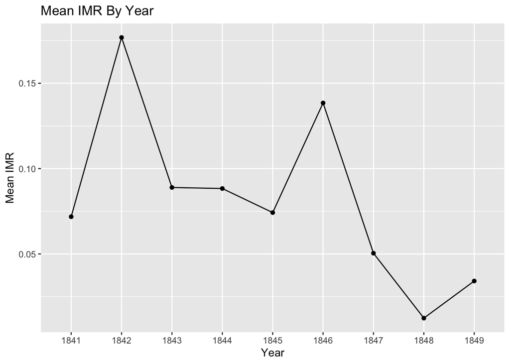

```r
monthly_deaths %>% group_by(year) %>% summarize(mean_imr=mean(infant_mor)) %>% ggplot (aes(x=year, y=mean_imr, group=1)) + geom_point () +geom_line() + labs(x="Year", y="Mean IMR", title="Mean IMR By Year")
```

**Question 1: Here, I plot Mean IMR by Month and alos run a command to smooth the data (as requested in question 3)** &nbsp

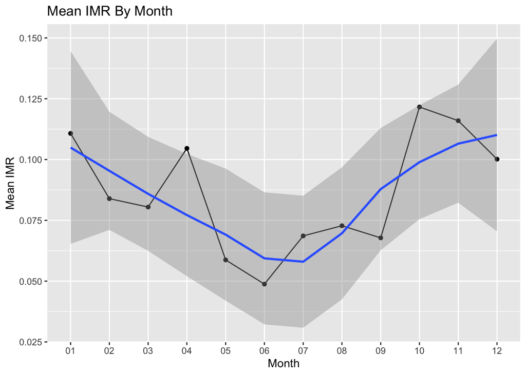

```r
monthly_deaths %>% group_by(month) %>% summarize(mean_imr=mean(infant_mor)) %>% ggplot (aes(x=month, y=mean_imr, group=1)) + geom_point () +geom_line() + labs(x="Month", y="Mean IMR", title="Mean IMR By Month")+ geom_smooth(method = "loess")
```

**Question 1: Here, I plot Mean IMR by Season**

```r
monthly_deaths$season<-recode(monthly_deaths$month, '01'="Winter", '02'="Winter", '03'="Spring", '04'="Spring", '05'="Spring", '06'="Summer", '07'="Summer", '08'="Summer", '09'="Fall", '10'="Fall", '11'="Fall", '12'="Winter")
```

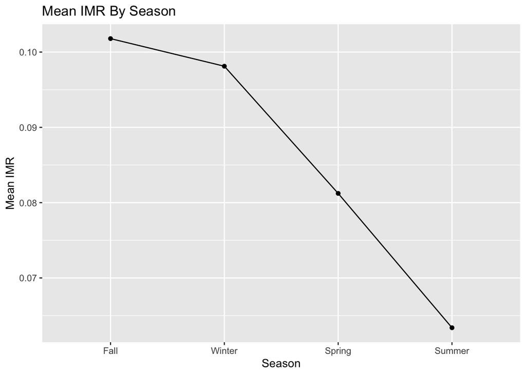

```r
monthly_deaths %>% group_by(season) %>% summarize(mean_imr=mean(infant_mor)) %>% ggplot (aes(x=factor(season, levels=c("Fall", "Winter", "Spring", "Summer")), y=mean_imr, group=1)) + geom_point () +geom_line() + labs(x="Season", y="Mean IMR", title="Mean IMR By Season")
```

**Question 2: Here, I plot Mean IMR by month differentiating between before and after hand-washing was introduced**

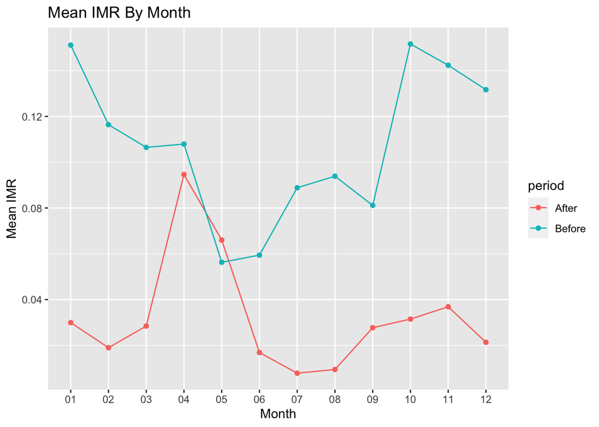

```r
monthly_deaths$period<-recode(monthly_deaths$year, '1841'="Before", '1842'="Before",  '1843'="Before",  '1844'="Before",  '1845'="Before", '1846'="Before",  '1847'="After",  '1848'="After",  '1849'="After")

monthly_deaths %>% group_by(month, period) %>% summarize(mean_imr=mean(infant_mor)) %>% ggplot (aes(x=month, y=mean_imr, group=period, color=period)) +geom_point() + geom_line() + labs(x="Month", y="Mean IMR", title="Mean IMR By Month")
```

**Question 3: Here, I run a regression to see the impact of handwashing on IMR. My results show that the introduction of handwashing DECREASES the mean IMR by 0.075 units**

```r
monthly_deaths$period2<-recode(monthly_deaths$period, 'Before'="0", 'After'="1")
mod<-lm(monthly_deaths$infant_mor~monthly_deaths$period2)
summary(mod)
```

```
##
## Call:
## lm(formula = monthly_deaths$infant_mor ~ monthly_deaths$period2)
##
## Residuals:
##       Min        1Q    Median        3Q       Max
## -0.101683 -0.043037 -0.003671  0.027383  0.206889
##
## Coefficients:
##                          Estimate Std. Error t value Pr(>|t|)
## (Intercept)              0.106918   0.007561  14.140  < 2e-16 ***
## monthly_deaths$period21 -0.075191   0.014406  -5.219 1.04e-06 ***
## ---
## Signif. codes:  0 '***' 0.001 '**' 0.01 '*' 0.05 '.' 0.1 ' ' 1
##
## Residual standard error: 0.06371 on 96 degrees of freedom
## Multiple R-squared:  0.2211, Adjusted R-squared:  0.2129
## F-statistic: 27.24 on 1 and 96 DF,  p-value: 1.036e-06
```

**Question 4: Here, I run a t-test to see if the effect of handwashing on IMR is significant. The results show that at 95% confidence level, the null hypothesis is to be rejected: the means of IMR before and after handwashing are significantly different**

```r
t.test(monthly_deaths$infant_mor~monthly_deaths$period2, mu=0, alt="two.sided", conf=0.95, var.ef=F, paired=F)
```

```
##
##  Welch Two Sample t-test
##
## data:  monthly_deaths$infant_mor by monthly_deaths$period2
## t = 6.7105, df = 84.198, p-value = 2.114e-09
## alternative hypothesis: true difference in means is not equal to 0
## 95 percent confidence interval:
##  0.05290915 0.09747238
## sample estimates:
## mean in group 0 mean in group 1
##      0.10691840      0.03172764
```

**Question 5: Here, I create the radarchart showing the seasonality of IMR**

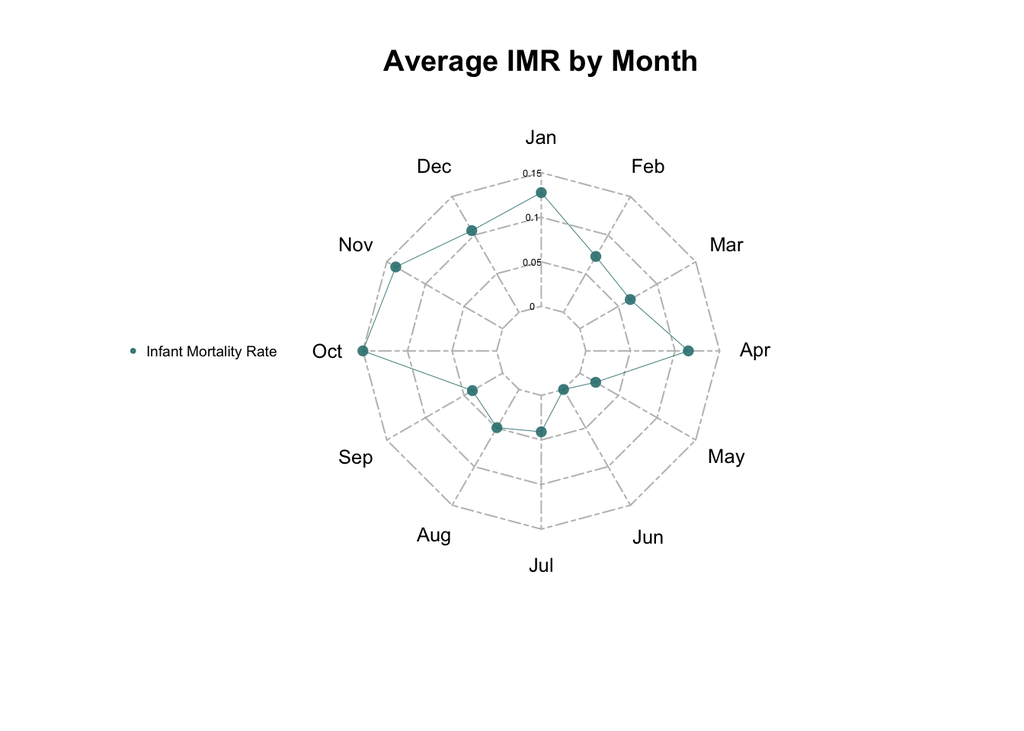

```r
monthly_deaths$month1<-strftime(monthly_deaths$date, "%b")


data1<-monthly_deaths %>% group_by(month1) %>% summarize(mean_imr=mean(infant_mor)) %>% pivot_wider(names_from = month1, values_from = mean_imr, names_sort = TRUE)
data1<-rbind(rep(0.1216015,10), rep(0.04877752,10), data1)


radarchart(data1[,c(5,3,10,11,12,2,6,7,9,1,8,4)], axistype=1, seg=3, title="Average IMR by Month", pcol=rgb(0.2,0.5,0.5,0.9) , plwd=0.5 , cglcol="grey", cglty=6, axislabcol="black", caxislabels=seq(0,0.15,0.05), cglwd=1, vlcex=0.8, calcex = 0.4)

legend(
  x = "left",y="right", legend = "Infant Mortality Rate", horiz = FALSE,
  bty = "n", pch = 20 , col = rgb(0.2,0.5,0.5,0.9),
  text.col = "black", cex = 0.6, pt.cex = 0.6
  )
```